# act_report

## Report: act_report

### INSIGHTS AND VISUALISATIONS FROM TWITTER DOGS’ RATING

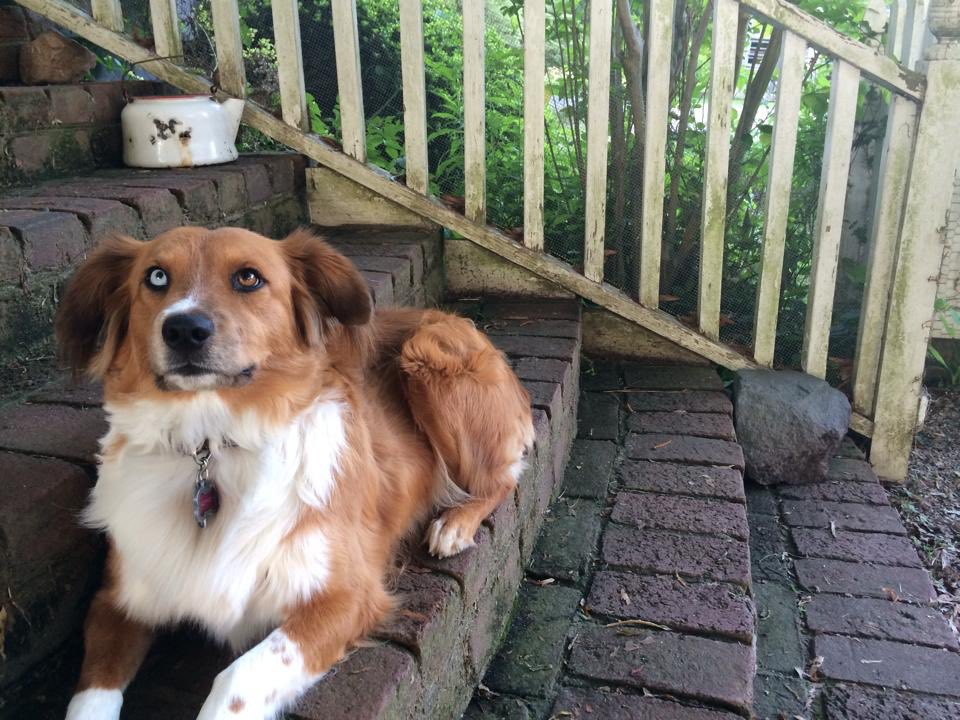

Based on the cleaned merged data, the following insights can be deduced: 1.Based on the data points for "favorite_counts and "dog-stage", we can have a deep understanding of what dog stage was the favourite. 2.We can have more insights on what dog had the most re-tweet based on the data points for "retweet_counts and "dog-stage", 3.The data points for "overall-rating" and "dog_stage" will provide more findings to detect the dog stage with the best rating.

### Visualisations

The following deduction can be derived from the Analytics from the visualization below:

#### Fig 1

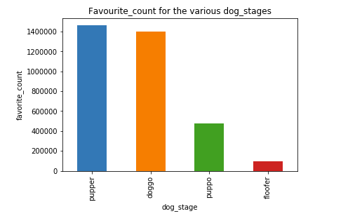

Considering fig 1, the dog stage which is pupper has the highest favourite counts followed by doggo then puppo and lastly floofer. This means that most people adore dogs when they are puppies.

#### Fig 2

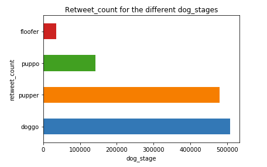

Based on fig 2, we can conclude that doggo has the highest retweet and engagement while floofer has the lowest.

#### Fig 3

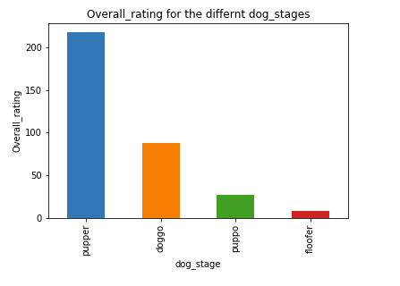

Fig 3 shows that the dog stage for pupper had the highest rating with a significant difference with the other variables.

#### Conclusion

We can conclude that the pupper dog stage had the highest rating because it had the highest favourite count. However, we need to investigate why pupper did not have the highest retweet or engagement, and doggo had the highest with less favourite counts and rating. As a result, the inability to discover and identify the motives behind the rating, retweet, and favourite counts is a limitation to the data analytics on the project as a whole.

With further research, more accurate conclusions can be deduced